# A Tutorial for Applying PCA of Waveforms in Biomechanics.

John Warmenhoven, Norma Bargary, Dominik Liebl, Andrew Harrison, Mark Robinson, Edward Gunning & Giles Hooker

## Load sample data

Data for this tutorial can be taken from the Functional Data Analysis website: http://www.psych.mcgill.ca/misc/fda/downloads/FDAfuns/Matlab/ (once the fdaM.zip folder is downloaded, data is located at 'fdaM\examples\gait')

For any questions related to this tutorial (and script), please email john.warmenhoven@hotmail.com.

The data can be loaded below (make sure this is in the same folder as your m-file).

load('gait');

This loads open access data collected at the Motion Analysis Laboratory at Children’s Hospital in California. Full details on the collection of the data can be found at Olshen, et al. (1989).

The data consists of hip and knee joint curves of 39 children. Each curve consists of 20 data points across the gait cycle. This tutorial will only focus on the knee joint.

## Principal Components Analysis (PCA) of Waveforms

Define the knee joint curves and transpose them in preparation for PCA.

Knee_Curves = knee';

The knees have been normalised to 20 data points using an interpolating cublic spline. Here they are centered within the time interval (which in this case after temporal normalization is percentage of the gait cycle).

time = linspace(0, 100, 20)';

The 'pca' function is an inbuilt Matlab function and can be applied to waveform data as a means of dimension reduction. This function returns co-efficients (x), which are principal components (PC), PC scores (y), eigenvalues (z) of the covariance matrix of 'Knee_Curves,' Hotelling's T-squared statistic for each observation (ii), and the percentage of the total variation attributed to each PC (iii).

[x,y,z,ii,iii] = pca(Knee_Curves);

Within the context of PCA of waveforms, the principal components (PC) themselves are time-series and can be observed graphically. See the figures below. Figure(1) shows PC1 and figure(2) shows PC2.

figure(1)

plot(time, x(:,1), 'k');

hold on

plot(time, zeros(20,1), 'k--')

hold off

axis([0 100 -0.3 0.5])

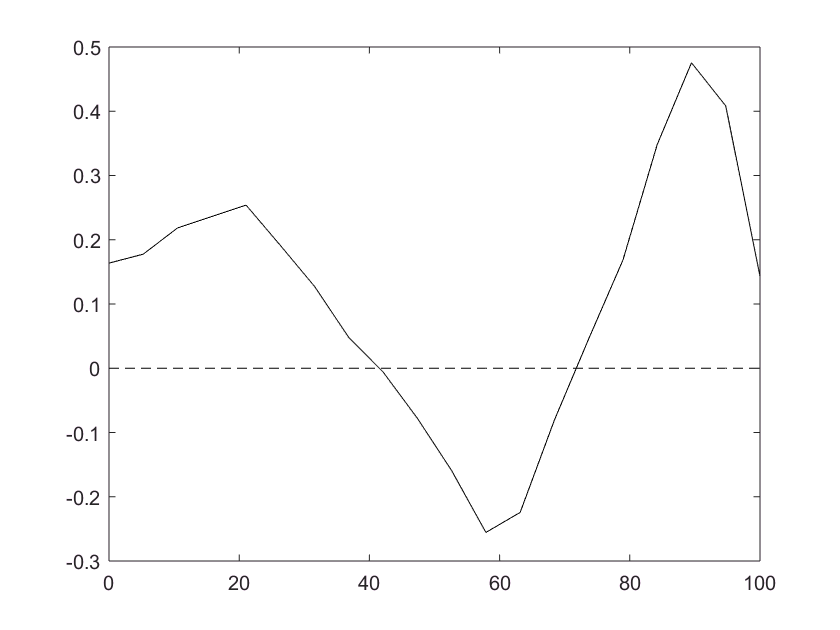

figure(2)

plot(time, x(:,2), 'k');

hold on

plot(time, zeros(20,1), 'k--')

hold off

axis([0 100 -0.3 0.5])

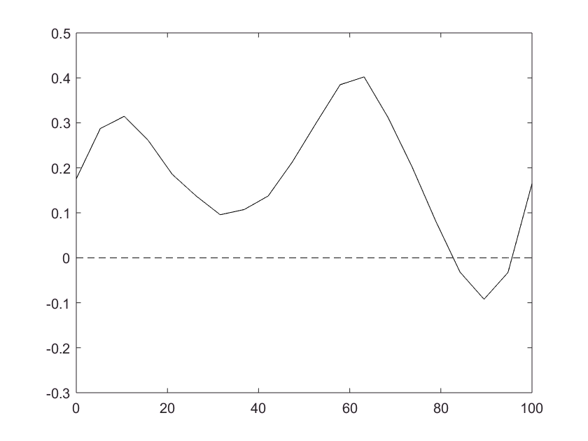

The PCs can also be observed from a more practical perspective by adding and subtracting them from the average/mean curve. To do this, first the mean curve is calculated:

mean_curve = mean(Knee_Curves);

## Visualising Results

Then a constant is created to scale each of the PCs before plotting them relative to the mean. A constant that is commonly used is 1 or 2 standard deviations (SD) of the PC scores. So an SD of PC scores is calculated for each PC.

stdevscores = std(y);

Then this is used to create the constant.

con1 = stdevscores(1)*1;

And then scaled PCs are added and subtracted from the mean curve, before being plotted with the mean curve.

PC1_Pos = mean_curve' + con1.*(x(:,1));

PC1_Neg = mean_curve' - con1.*(x(:,1));

Figure(3) shows PC1, with positive scorers plotted using the '+' symbols and negative scorers plotted using the '-' symbols.

figure(3)

phdl = plot(time, mean_curve', 'k-');

set(phdl, 'LineWidth', 1)

hold on

phdl = text(time, PC1_Pos, '+');

set(phdl, 'LineWidth', 1)

hold on

phdl = text(time, PC1_Neg, '-');

set(phdl, 'LineWidth', 1)

hold off

box on

set(gca,'FontSize',10);

title('\fontsize{10} PC1');

xlabel('\fontsize{10} Gait Cycle (%)')

ylabel('\fontsize{10} Knee Angle (°)')

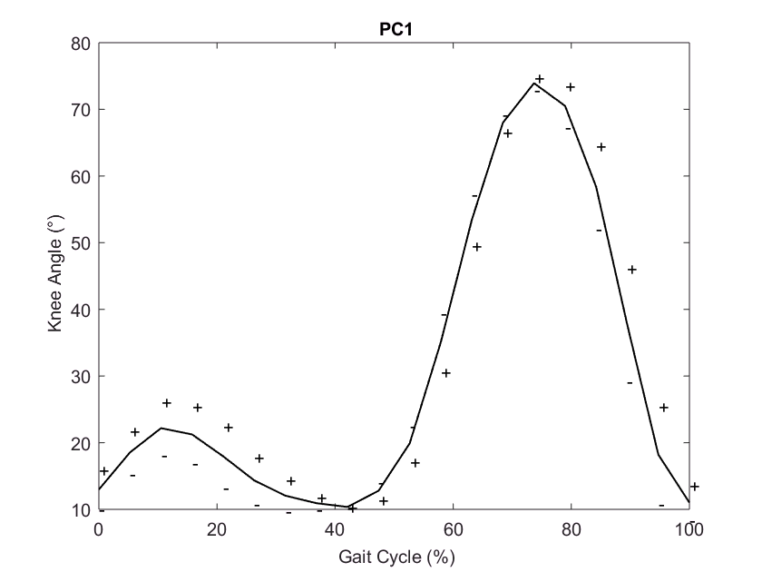

The same process is also carried out for PC2. Inclusive of creating a constant to scale the second PC.

con2 = stdevscores(2)*1;

PC2_Pos = mean_curve' + con2.*(x(:,2));

PC2_Neg = mean_curve' - con2.*(x(:,2));

figure(4)

phdl = plot(time, mean_curve', 'k-');

set(phdl, 'LineWidth', 1)

hold on

phdl = text(time, PC2_Pos, '+');

set(phdl, 'LineWidth', 1)

hold on

phdl = text(time, PC2_Neg, '-');

set(phdl, 'LineWidth', 1)

hold off

box on

set(gca,'FontSize',10);

title('\fontsize{10} PC2');

xlabel('\fontsize{10} Gait Cycle (%)')

ylabel('\fontsize{10} Knee Angle (°)')

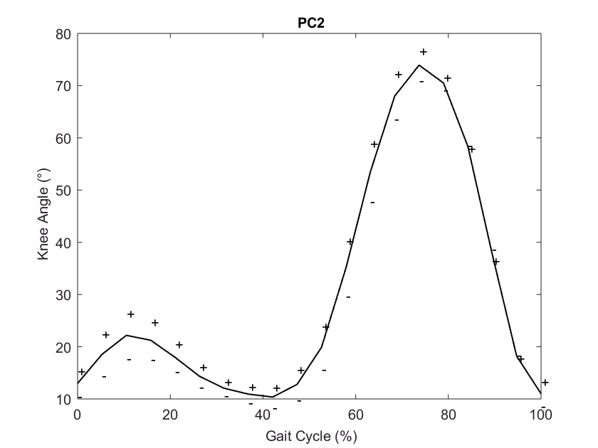

An example of a way to graph the principal component scores can also be seen below, plotting scores for one PC1 relative to PC2.

figure(5)

scatter(y(:,1),y(:,2), 'k');

box on

set(gca,'FontSize',10);

title('\fontsize{10} PC1 vs PC2');

xlabel('\fontsize{10} PC1 Scores')

ylabel('\fontsize{10} PC2 Scores')

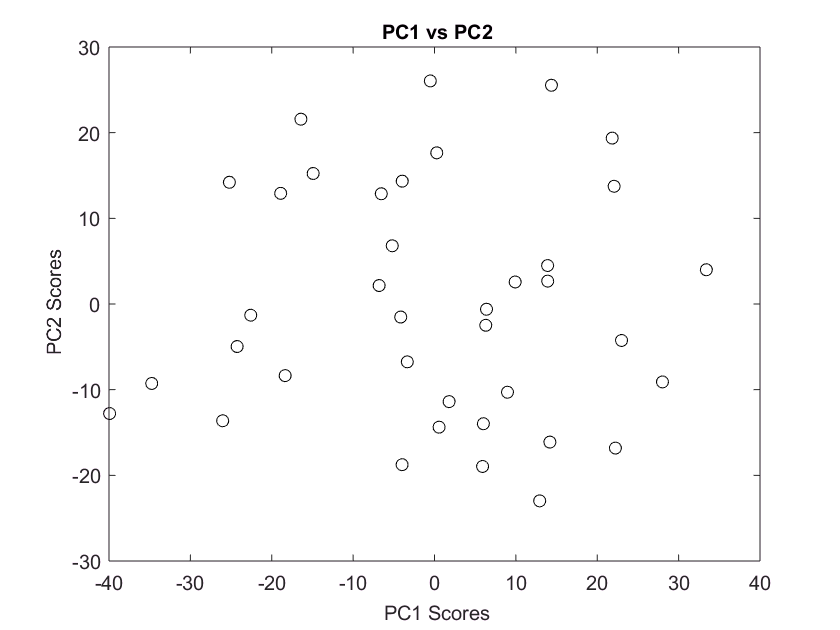

## References

Olshen, R. A., Biden, E. N., Wyatt, M. P. & Sutherland, D. H. (1989). Gait analysis and the bootstrap. The Annals of Statistics, 1419-1440.